# HW 3

Using the “KamilarAndCooperData.csv” dataset, run a linear regression looking at log(MeanGroupSize) in relation to log(Body_mass_female_mean) and report your  
βcoeffiecients (slope and intercept). Then, use bootstrapping to sample from the dataset 1000 times with replacement, each time fitting the same model and calculating the appropriate coefficients. [The size of each sample should be equivalent to the total number of observations in the dataset.] This generates a bootstrap sampling distribution for each  
β coefficient. Plot a histogram of these sampling distributions for  
β0 and β1 Estimate the standard error for each of your  
β coefficients as the standard deviation of the sampling distribution from your bootstrap. Also determine the 95% CI for each of your  
β coefficients based on the appropriate quantiles from your sampling distribution. How do the SEs estimated from the bootstrap sampling distribution compare to those estimated mathematically as part of lm() function? How do your bootstrap CIs compare to those estimated mathematically as part of the lm() function?

```r
d=na.omit(d)
d$log_gs<-log(d$MeanGroupSize)
d$log_fbm<-log(d$Body_mass_female_mean)
lm_1<-lm(log_gs ~ log_fbm, data=d)
summary(lm_1)
```

```
##
## Call:
## lm(formula = log_gs ~ log_fbm, data = d)
##
## Residuals:
##      Min       1Q   Median       3Q      Max
## -2.03970 -0.57556  0.01865  0.59171  1.48135
##
## Coefficients:
##             Estimate Std. Error t value Pr(>|t|)
## (Intercept)   1.1426     1.4353   0.796    0.435
## log_fbm       0.1512     0.1637   0.923    0.366
##
## Residual standard error: 0.9815 on 22 degrees of freedom
## Multiple R-squared:  0.03731,    Adjusted R-squared:  -0.006447
## F-statistic: 0.8527 on 1 and 22 DF,  p-value: 0.3658
```

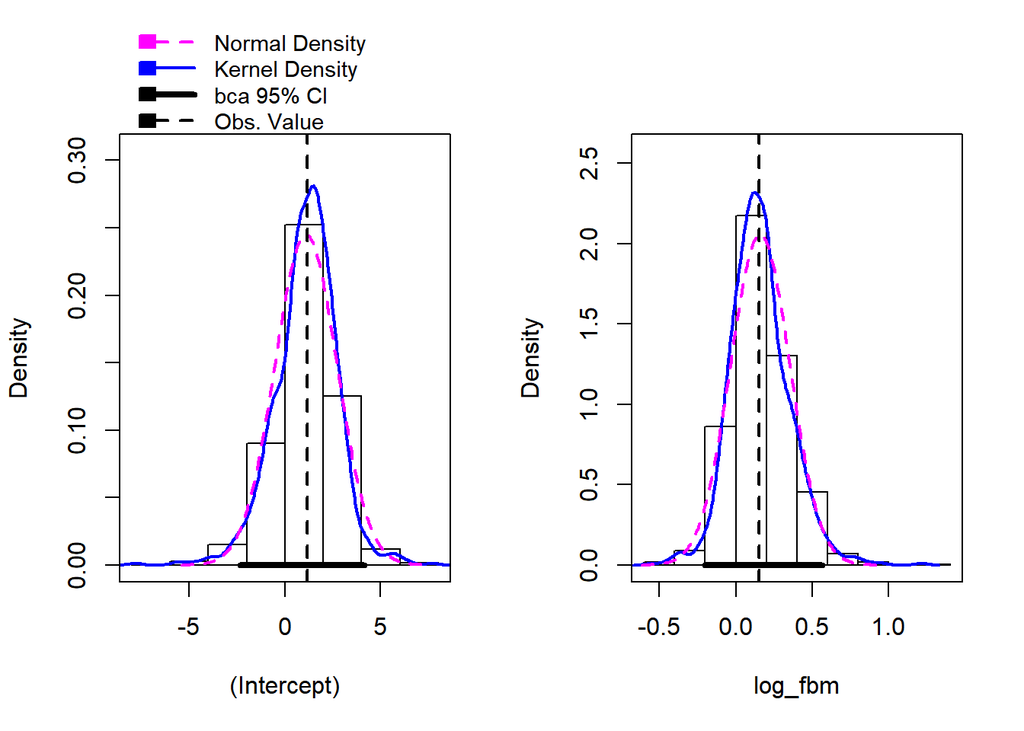

```r
boot.coefs <- Boot(lm_1, f=coef, R=1000)
hist(boot.coefs)
```

```r
summary(boot.coefs)
```

```
##
## Number of bootstrap replications R = 1000
##             original   bootBias  bootSE bootMed
## (Intercept)   1.1426 -0.0527991 1.62839 1.23054
## log_fbm       0.1512  0.0075283 0.19394 0.14198
```

```r
confint(boot.coefs, level=0.95, type="norm")
```

```
## Bootstrap normal confidence intervals
##
##                  2.5 %    97.5 %
## (Intercept) -1.9961787 4.3870045
## log_fbm     -0.2364338 0.5237818
```

```r
confint(lm_1, level=0.95, type="norm")
```

```
##                 2.5 %    97.5 %
## (Intercept) -1.834085 4.1193127
## log_fbm     -0.188385 0.4907895
```

CHALLENGE 3: Write your own function, called boot_lm(), that takes as its arguments a dataframe (d=), a linear model (model=, written as a character string, e.g., “logGS ~ logBM”), a user-defined confidence interval level (conf.level=, with default “0.95”), and a number of bootstrap replicates (reps=, with default “1000”).

Your function should return a dataframe that includes: the  
βcoefficient names ( β0,β1, etc.); the value of the  
β coefficients, their standard errors, and their upper and lower CI limits for the linear model based on your original dataset; and the mean  
βcoefficient estimates, SEs, and CI limits for those coefficients based on your bootstrap. Use your function to run the following models on the “KamilarAndCooperData.csv” dataset: log(MeanGroupSize) ~ log(Body_mass_female_mean) log(DayLength_km) ~ log(Body_mass_female_mean) log(DayLength_km) ~ log(Body_mass_female_mean) + log(MeanGroupSize)

```r
  boot_lm <- function(d, model, reps) {
  original.est <- get(model)(d)

  n_est <- length(original.est)
  temp <- matrix(NA, ncol = n_est , nrow = reps)
  nobs <- nrow(d)
  for (i in 1:reps) {
    posdraws <- ceiling(runif(nobs)*nobs)
    draw <- d[posdraws,]
    temp[i,] <- get(model)(draw)
  }
  sds <- apply(temp,2,sd)
  CI <- apply(temp, 2, quantile, probs = c(0.025, 0.975))
  print(rbind(original.est, sds, CI))
  return(list(estimates=temp, sds=sds))
  }
  gs_fbm <- function(d) lm(d$log_gs ~ d$log_fbm)[[1]]
gs_fbm.res<-boot_lm(d, "gs_fbm", reps=1000)
```

```
##              (Intercept)  d$log_fbm
## original.est    1.142614  0.1512023
## sds             1.613929  0.1908489
## 2.5%           -2.179414 -0.1990888
## 97.5%           4.181391  0.5462541
```

```r
d$log_dl<-log(d$DayLength_km)
dl_fbm <- function(d) lm(d$log_dl ~ d$log_fbm)[[1]]
dl_fbm.res<-boot_lm(d, "dl_fbm", reps=1000)
```

```
##              (Intercept)   d$log_fbm
## original.est  -0.3925435  0.04843659
## sds            1.0138704  0.12193567
## 2.5%          -2.7134555 -0.16064001
## 97.5%          1.3077412  0.31907734
```

```r
dl_fbm_gs <- function(d) lm((d$log_dl) ~ (d$log_fbm) + (d$log_gs))[[1]]
dl_fbm_gs.res<-boot_lm(d, "dl_fbm", reps=1000)
```

[output not shown]

```
##              (Intercept)   d$log_fbm
## original.est  -0.3925435  0.04843659
## sds            1.0195942  0.12219079
## 2.5%          -2.9894010 -0.15239491
## 97.5%          1.2728546  0.34629176
```